# * Prerequisites

In this assignment you will implement the Naive Bayes Classifier. Before starting this assignment, make sure you understand the concepts discussed in the videos in Week 2 about Naive Bayes. You can also find it useful to read Chapter 1 of the textbook.

Also, make sure that you are familiar with the `numpy.ndarray` class of python's `numpy` library and that you are able to answer the following questions:

Let's assume `a` is a numpy array.

- What is an array's shape (e.g., what is the meaning of `a.shape`)?
- What is numpy's reshaping operation? How much computational over-head would it induce?
- What is numpy's transpose operation, and how it is different from reshaping? Does it cause computation overhead?
- What is the meaning of the commands `a.reshape(-1, 1)` and `a.reshape(-1)`?
- Would happens to the variable `a` after we call `b = a.reshape(-1)`? Does any of the attributes of `a` change?
- How do assignments in python and numpy work in general?
  - Does the `b=a` statement use copying by value? Or is it copying by reference?
  - Would the answer to the previous question change depending on whether `a` is a numpy array or a scalar value?

You can answer all of these questions by

```
1. Reading numpy's documentation from https://numpy.org/doc/stable/.
2. Making trials using dummy variables.
```

# *Assignment Summary

The UC Irvine machine learning data repository hosts a famous dataset, the Pima Indians dataset, on whether a patient has diabetes originally owned by the National Institute of Diabetes and Digestive and Kidney Diseases and donated by Vincent Sigillito. You can find it at https://www.kaggle.com/uciml/pima-indians-diabetes-database/data. This data has a set of attributes of patients, and a categorical variable telling whether the patient is diabetic or not. For several attributes in this data set, a value of 0 may indicate a missing value of the variable. It has a total of 768 data-points.

- **Part 1-A)** First, you will build a simple naive Bayes classifier to classify this data set. We will use 20% of the data for evaluation and the other 80% for training.

  You should use a normal distribution to model each of the class-conditional distributions.  
  (**Class conditional probability** is the probability of each attribute value for an attribute, for each outcome value.  
  https://www.sciencedirect.com/topics/mathematics/conditional-probability)  
  (The **posterior probability** is calculated by updating the prior probability using Bayes' theorem.)

  Report the accuracy of the classifier on the 20% evaluation data, where accuracy is the number of correct predictions as a fraction of total predictions.
- **Part 1-B)** Next, you will adjust your code so that, for attributes 3 (Diastolic blood pressure), 4 (Triceps skin fold thickness), 6 (Body mass index), and 8 (Age), it **regards a value of 0 as a missing value** when estimating the class-conditional distributions, and the posterior.

  Report the accuracy of the classifier on the 20% that was held out for evaluation.
- **Part 1-C)** Last, you will have some experience with SVMLight, an off-the-shelf implementation of Support Vector Machines or SVMs. For now, you don't need to understand much about SVM's, we will explore them in more depth in the following exercises. You will install SVMLight, which you can find at http://svmlight.joachims.org, to train and evaluate an SVM to classify this data.

  **You should NOT substitute NA values for zeros for attributes 3, 4, 6, and 8.**

  Report the accuracy of the classifier on the held out 20%

# 0. Data

## 0.1 Description

The UC Irvine's Machine Learning Data Repository Department hosts a Kaggle Competition with famous collection of data on whether a patient has diabetes (the Pima Indians dataset), originally owned by the National Institute of Diabetes and Digestive and Kidney Diseases and donated by Vincent Sigillito.

You can find this data at https://www.kaggle.com/uciml/pima-indians-diabetes-database/data. The Kaggle website offers valuable visualizations of the original data dimensions in its dashboard. It is quite insightful to take the time and make sense of the data using their dashboard before applying any method to the data.

## 0.2 Information Summary

- **Input/Output**: This data has a set of attributes of patients, and a categorical variable telling whether the patient is diabetic or not.
- **Missing Data**: For **several** attributes in this data set, a value of 0 may indicate a missing value of the variable.
- **Final Goal**: We want to build a classifier that can predict whether a patient has diabetes or not. To do this, we will train multiple kinds of models, and will be **handing the missing data with different approaches for each method** (i.e., some methods will ignore their existence, while others may do something about the missing data).

## 0.3 Loading

```python
%matplotlib inline
import pandas as pd
import numpy as np
import seaborn as sns
import matplotlib.pyplot as plt

from aml_utils import test_case_checker
```

```python
df = pd.read_csv('../BasicClassification-lib/diabetes.csv')
df.head()
```

|  | Pregnancies | Glucose | BloodPressure | SkinThickness | Insulin | BMI | DiabetesPedigreeFunction | Age | Outcome |
| --- | --- | --- | --- | --- | --- | --- | --- | --- | --- |
| 0 | 6 | 148 | 72 | 35 | 0 | 33.6 | 0.627 | 50 | 1 |
| 1 | 1 | 85 | 66 | 29 | 0 | 26.6 | 0.351 | 31 | 0 |
| 2 | 8 | 183 | 64 | 0 | 0 | 23.3 | 0.672 | 32 | 1 |
| 3 | 1 | 89 | 66 | 23 | 94 | 28.1 | 0.167 | 21 | 0 |
| 4 | 0 | 137 | 40 | 35 | 168 | 43.1 | 2.288 | 33 | 1 |

## 0.1 Splitting The Data

First, we will shuffle the data completely, and forget about the order in the original csv file.

- The training and evaluation dataframes will be named `train_df` and `eval_df`, respectively.
- We will also create the 2-d numpy array `train_features` whose number of rows is the number of training samples, and the number of columns is 8 (i.e., the number of features). We will define `eval_features` in a similar fashion
- We would also create the 1-d numpy arrays `train_labels` and `eval_labels` which contain the training and evaluation labels, respectively.

```python
# Let's generate the split ourselves.
np_random = np.random.RandomState(seed=12345) #??
rand_unifs = np_random.uniform(0,1,size=df.shape[0]) #produce N random numbers from Unif distribution
division_thresh = np.percentile(rand_unifs, 80) # return 80th %ile of the random numbers
train_indicator = rand_unifs < division_thresh # train_indicator = 1 if random number < 80th %ile
eval_indicator = rand_unifs >= division_thresh # eval_indicator = 1 if random number >= 80th %ile
```

```python
train_df = df[train_indicator].reset_index(drop=True) #use training obs indicator to create a training dataframe, df
train_features = train_df.loc[:, train_df.columns != 'Outcome'].values #training featurs are all, but the outcome
train_labels = train_df['Outcome'].values # outcome column is the labels vector
train_df.head()
```

|  | Pregnancies | Glucose | BloodPressure | SkinThickness | Insulin | BMI | DiabetesPedigreeFunction | Age | Outcome |
| --- | --- | --- | --- | --- | --- | --- | --- | --- | --- |
| 0 | 1 | 85 | 66 | 29 | 0 | 26.6 | 0.351 | 31 | 0 |
| 1 | 8 | 183 | 64 | 0 | 0 | 23.3 | 0.672 | 32 | 1 |
| 2 | 1 | 89 | 66 | 23 | 94 | 28.1 | 0.167 | 21 | 0 |
| 3 | 0 | 137 | 40 | 35 | 168 | 43.1 | 2.288 | 33 | 1 |
| 4 | 5 | 116 | 74 | 0 | 0 | 25.6 | 0.201 | 30 | 0 |

```python
#similarly to above create features df and outcome vector for evaluation/testing
eval_df = df[eval_indicator].reset_index(drop=True)
eval_features = eval_df.loc[:, eval_df.columns != 'Outcome'].values
eval_labels = eval_df['Outcome'].values
eval_df.head()
```

|  | Pregnancies | Glucose | BloodPressure | SkinThickness | Insulin | BMI | DiabetesPedigreeFunction | Age | Outcome |
| --- | --- | --- | --- | --- | --- | --- | --- | --- | --- |
| 0 | 6 | 148 | 72 | 35 | 0 | 33.6 | 0.627 | 50 | 1 |
| 1 | 3 | 78 | 50 | 32 | 88 | 31.0 | 0.248 | 26 | 1 |
| 2 | 10 | 168 | 74 | 0 | 0 | 38.0 | 0.537 | 34 | 1 |
| 3 | 0 | 118 | 84 | 47 | 230 | 45.8 | 0.551 | 31 | 1 |
| 4 | 7 | 107 | 74 | 0 | 0 | 29.6 | 0.254 | 31 | 1 |

```python
train_features.shape, train_labels.shape, eval_features.shape, eval_labels.shape
```

```
((614, 8), (614,), (154, 8), (154,))
```

There are 614 obs for training, 154 for testing and 8 features

## 0.2 Pre-processing The Data

Some of the columns exhibit missing values. We will use a Naive Bayes Classifier later that will treat such missing values in a special way. To be specific, for attribute 3 (Diastolic blood pressure), attribute 4 (Triceps skin fold thickness), attribute 6 (Body mass index), and attribute 8 (Age), we should regard a value of 0 as a missing value.

Therefore, we will be creating the `train_featues_with_nans` and `eval_features_with_nans` numpy arrays to be just like their `train_features` and `eval_features` counter-parts, but with the zero-values in such columns replaced with nans.

```python
train_df_with_nans = train_df.copy(deep=True)
eval_df_with_nans = eval_df.copy(deep=True)
for col_with_nans in ['BloodPressure', 'SkinThickness', 'BMI', 'Age']:
    train_df_with_nans[col_with_nans] = train_df_with_nans[col_with_nans].replace(0, np.nan) #replace(0, np.nan)
    eval_df_with_nans[col_with_nans] = eval_df_with_nans[col_with_nans].replace(0, np.nan)
train_features_with_nans = train_df_with_nans.loc[:, train_df_with_nans.columns != 'Outcome'].values
eval_features_with_nans = eval_df_with_nans.loc[:, eval_df_with_nans.columns != 'Outcome'].values
```

pandas.DataFrame.loc: Access a group of rows and columns by label(s) or a boolean array.

pandas.DataFrame.values property: DataFrame.values Return a Numpy representation of the DataFrame, ie numpy.ndarray where only the values in the dataFrame will be returned, the axes labels will be removed. Warning: We recommend using DataFrame.to_numpy() instead.

```python
print('Here are the training rows with at least one missing values.')
print('')
print('You can see that such incomplete data points constitute a substantial part of the data.')
print('')
#Show only the rows with missing values:
nan_training_data = train_df_with_nans[train_df_with_nans.isna().any(axis=1)]
nan_training_data
#len(nan_training_data)/len(train_df_with_nans)
#30%
```

```
Here are the training rows with at least one missing values.

You can see that such incomplete data points constitute a substantial part of the data.
```

|  | Pregnancies | Glucose | BloodPressure | SkinThickness | Insulin | BMI | DiabetesPedigreeFunction | Age | Outcome |
| --- | --- | --- | --- | --- | --- | --- | --- | --- | --- |
| 1 | 8 | 183 | 64.0 | NaN | 0 | 23.3 | 0.672 | 32 | 1 |
| 4 | 5 | 116 | 74.0 | NaN | 0 | 25.6 | 0.201 | 30 | 0 |
| 5 | 10 | 115 | NaN | NaN | 0 | 35.3 | 0.134 | 29 | 0 |
| 7 | 8 | 125 | 96.0 | NaN | 0 | NaN | 0.232 | 54 | 1 |
| 8 | 4 | 110 | 92.0 | NaN | 0 | 37.6 | 0.191 | 30 | 0 |
| ... | ... | ... | ... | ... | ... | ... | ... | ... | ... |
| 598 | 6 | 162 | 62.0 | NaN | 0 | 24.3 | 0.178 | 50 | 1 |
| 599 | 4 | 136 | 70.0 | NaN | 0 | 31.2 | 1.182 | 22 | 1 |
| 605 | 1 | 106 | 76.0 | NaN | 0 | 37.5 | 0.197 | 26 | 0 |
| 606 | 6 | 190 | 92.0 | NaN | 0 | 35.5 | 0.278 | 66 | 1 |
| 612 | 1 | 126 | 60.0 | NaN | 0 | 30.1 | 0.349 | 47 | 1 |

186 rows × 9 columns

df.isna(): Return a boolean same-sized object indicating if the values are NA. NA values, such as None or numpy.NaN, get mapped to True values. **pandas.DataFrame.any**  
DataFrame.any(axis=0) Return whether any element is True, potentially over an axis.

Returns False unless there is at least one element within a series or along a Dataframe axis that is True or equivalent (e.g. non-zero or non-empty).

axis{0 or ‘index’, 1 or ‘columns’, None}

- 0 / ‘index’ : reduce/eliminate the index, return a Series whose index is the original column labels.
- 1 / ‘columns’ : reduce/eliminate the columns, return a Series whose index is the original index.
- None : reduce all axes, return a scalar.

# 1. Part 1 (Building a simple Naive Bayes Classifier)

Consider a single sample (or observation) $(\mathbf{x}, y)$, where the feature vector is denoted with $\mathbf{x}$, and the label is denoted with $y$. We will also denote the $j^{th}$ feature of $\mathbf{x}$ with $x^{(j)}$.

According to the textbook, the Naive Bayes Classifier uses the following decision rule:

"Choose $y$ such that $$\bigg[\log p(y) + \sum_{j} \log p(x^{(j)}|y) \bigg]$$ is the largest"

However, we first need to define the probabilistic models (ie: the PDFs) of the prior $p(y)$ and the class-conditional feature distributions $p(x^{(j)}|y)$ using the training data.

- **Modelling the prior $p(y)$**: We fit a Bernoulli distribution to the `Outcome` variable of `train_df`.
- **Modelling the class-conditional feature distributions $p(x^{(j)}|y)$**: We fit Gaussian distributions, and infer the Gaussian mean and variance parameters from `train_df`.

# Task 1

Write a function `log_prior` that takes a numpy array `train_labels` as input, and outputs the following vector as a column numpy array (i.e., with shape $(2,1)$).

$$\log p_y =\begin{bmatrix}\log p(y=0)\\\log p(y=1)\end{bmatrix}$$

Try and avoid the utilization of loops as much as possible. No loops are necessary.

**Hint**: Make sure all the array shapes are what you need and expect. You can reshape any numpy array without any tangible computational over-head.  
$P_𝑦$ **is log of the prior probabiliy.**

```python
    log_py = np.array( [1-sum(train_labels)/len(train_labels), sum(train_labels)/len(train_labels)] ).reshape(2, 1)
    #log_py.shape
    #sum(train_labels)/len(train_labels)
    log_py
```

```
array([[0.65960912],
       [0.34039088]])
```

```python
def log_prior(train_labels):

    log_py = np.array( [np.log(1-sum(train_labels)/len(train_labels)), np.log(sum(train_labels)/len(train_labels))] ).reshape(2, 1)
    assert log_py.shape == (2,1)

    return log_py
```

```python
# Performing sanity checks on your implementation
some_labels = np.array([0, 1, 0, 1, 0, 0, 1, 1, 0, 0, 1, 1, 1, 1, 0, 0, 1, 1, 1, 1])
some_log_py = log_prior(some_labels)
assert np.array_equal(some_log_py.round(3), np.array([[-0.916], [-0.511]]))

# Checking against the pre-computed test database
test_results = test_case_checker(log_prior, task_id=1)
assert test_results['passed'], test_results['message']
```

```python
# This cell is left empty as a seperator. You can leave this cell as it is, and you should not delete it.
```

```python
log_py = log_prior(train_labels)
log_py
```

```
array([[-0.41610786],
       [-1.07766068]])
```

# Task 2

Write a function `cc_mean_ignore_missing` that takes the numpy arrays `train_features` and `train_labels` as input, and outputs the following matrix with the shape $(8,2)$, where 8 is the number of features.

$$\mu_y = \begin{bmatrix} \mathbb{E}[x^{(0)}|y=0] & \mathbb{E}[x^{(0)}|y=1]\\ \mathbb{E}[x^{(1)}|y=0] & \mathbb{E}[x^{(1)}|y=1] \\ \cdots & \cdots\\ \mathbb{E}[x^{(7)}|y=0] & \mathbb{E}[x^{(7)}|y=1]\end{bmatrix}$$

Some points regarding this task:

- The `train_features` numpy array has a shape of `(N,8)` where `N` is the number of training data points, and 8 is the number of the features.
- The `train_labels` numpy array has a shape of `(N,)`.
- **You can assume that `train_features` has no missing elements in this task**.
- Try and avoid the utilization of loops as much as possible. No loops are necessary.

**Thought process notes:**

- need train features where train_labels are 0 vs. 1
- need sum $X^{(i)}$ where y = 0 and count $X^{(i)}$, where y = 1

```python
def cc_mean_ignore_missing(train_features, train_labels):
    N, d = train_features.shape

    E_yeq1 = np.mean(train_features[(train_labels == 1)], axis = 0)
    E_yeq0 = np.mean(train_features[(train_labels == 0)], axis = 0)

    #combine into list, convert to array, transpose
    mu_y = np.array([E_yeq0, E_yeq1]).T
    assert mu_y.shape == (d, 2)
    return mu_y
```

```python
# Performing sanity checks on your implementation
some_feats = np.array([[  1. ,  85. ,  66. ,  29. ,   0. ,  26.6,   0.4,  31. ],
                       [  8. , 183. ,  64. ,   0. ,   0. ,  23.3,   0.7,  32. ],
                       [  1. ,  89. ,  66. ,  23. ,  94. ,  28.1,   0.2,  21. ],
                       [  0. , 137. ,  40. ,  35. , 168. ,  43.1,   2.3,  33. ],
                       [  5. , 116. ,  74. ,   0. ,   0. ,  25.6,   0.2,  30. ]])
some_labels = np.array([0, 1, 0, 1, 0])

some_mu_y = cc_mean_ignore_missing(some_feats, some_labels)

assert np.array_equal(some_mu_y.round(2), np.array([[  2.33,   4.  ],
                                                    [ 96.67, 160.  ],
                                                    [ 68.67,  52.  ],
                                                    [ 17.33,  17.5 ],
                                                    [ 31.33,  84.  ],
                                                    [ 26.77,  33.2 ],
                                                    [  0.27,   1.5 ],
                                                    [ 27.33,  32.5 ]]))

# Checking against the pre-computed test database
test_results = test_case_checker(cc_mean_ignore_missing, task_id=2)
assert test_results['passed'], test_results['message']
```

```python
# This cell is left empty as a seperator. You can leave this cell as it is, and you should not delete it.
```

```python
mu_y = cc_mean_ignore_missing(train_features, train_labels)
mu_y
```

```
array([[  3.48641975,   4.91866029],
       [109.99753086, 142.30143541],
       [ 68.77037037,  70.66028708],
       [ 19.51358025,  21.97129187],
       [ 66.25679012, 100.55980861],
       [ 30.31703704,  35.1492823 ],
       [  0.42825926,   0.55279904],
       [ 31.57283951,  37.39712919]])
```

# Task 3

Write a function `cc_std_ignore_missing` that takes the numpy arrays `train_features` and `train_labels` as input, and outputs the following matrix with the shape $(8,2)$, where 8 is the number of features.

$$\sigma_y = \begin{bmatrix} \text{std}[x^{(0)}|y=0] & \text{std}[x^{(0)}|y=1]\\ \text{std}[x^{(1)}|y=0] & \text{std}[x^{(1)}|y=1] \\ \cdots & \cdots\\ \text{std}[x^{(7)}|y=0] & \text{std}[x^{(7)}|y=1]\end{bmatrix}$$

Some points regarding this task:

- The `train_features` numpy array has a shape of `(N,8)` where `N` is the number of training data points, and 8 is the number of the features.
- The `train_labels` numpy array has a shape of `(N,)`.
- **You can assume that `train_features` has no missing elements in this task**.
- Try and avoid the utilization of loops as much as possible. No loops are necessary.

```python
def cc_std_ignore_missing(train_features, train_labels):
    N, d = train_features.shape

    std_yeq1 = np.std(train_features[(train_labels == 1)], axis = 0)
    std_yeq0 = np.std(train_features[(train_labels == 0)], axis = 0)
    #combine into list, convert to array, transpose
    sigma_y = np.array([std_yeq0, std_yeq1]).T
    assert sigma_y.shape == (d, 2)

    return sigma_y
```

```python
# Performing sanity checks on your implementation
some_feats = np.array([[  1. ,  85. ,  66. ,  29. ,   0. ,  26.6,   0.4,  31. ],
                       [  8. , 183. ,  64. ,   0. ,   0. ,  23.3,   0.7,  32. ],
                       [  1. ,  89. ,  66. ,  23. ,  94. ,  28.1,   0.2,  21. ],
                       [  0. , 137. ,  40. ,  35. , 168. ,  43.1,   2.3,  33. ],
                       [  5. , 116. ,  74. ,   0. ,   0. ,  25.6,   0.2,  30. ]])
some_labels = np.array([0, 1, 0, 1, 0])

some_std_y = cc_std_ignore_missing(some_feats, some_labels)

assert np.array_equal(some_std_y.round(3), np.array([[ 1.886,  4.   ],
                                                     [13.768, 23.   ],
                                                     [ 3.771, 12.   ],
                                                     [12.499, 17.5  ],
                                                     [44.312, 84.   ],
                                                     [ 1.027,  9.9  ],
                                                     [ 0.094,  0.8  ],
                                                     [ 4.497,  0.5  ]]))

# Checking against the pre-computed test database
test_results = test_case_checker(cc_std_ignore_missing, task_id=3)
assert test_results['passed'], test_results['message']
```

```python
# This cell is left empty as a seperator. You can leave this cell as it is, and you should not delete it.
```

```python
sigma_y = cc_std_ignore_missing(train_features, train_labels)
sigma_y
```

```
array([[  3.1155426 ,   3.75417931],
       [ 25.96811899,  32.50910874],
       [ 18.07540068,  21.69568568],
       [ 15.02320635,  17.21685884],
       [ 95.63339586, 139.24364214],
       [  7.50030986,   6.6625219 ],
       [  0.29438217,   0.37201494],
       [ 11.67577435,  11.01543899]])
```

# Task 4

Write a function `log_prob` that takes the numpy arrays `train_features`, $\mu_y$, $\sigma_y$, and $\log p_y$ as input, and outputs the following matrix with the shape $(N, 2)$

**IN:** $$\log p_y =\begin{bmatrix}\log p(y=0)\\\log p(y=1)\end{bmatrix}$$

$$\mu_y = \begin{bmatrix} \mathbb{E}[x^{(0)}|y=0] & \mathbb{E}[x^{(0)}|y=1]\\ \mathbb{E}[x^{(1)}|y=0] & \mathbb{E}[x^{(1)}|y=1] \\ \cdots & \cdots\\ \mathbb{E}[x^{(7)}|y=0] & \mathbb{E}[x^{(7)}|y=1]\end{bmatrix}$$

$$\sigma_y = \begin{bmatrix} \text{std}[x^{(0)}|y=0] & \text{std}[x^{(0)}|y=1]\\ \text{std}[x^{(1)}|y=0] & \text{std}[x^{(1)}|y=1] \\ \cdots & \cdots\\ \text{std}[x^{(7)}|y=0] & \text{std}[x^{(7)}|y=1]\end{bmatrix}$$

**OUT:** $$\log p_{x,y} = \begin{bmatrix} \bigg[\log p(y=0) + \sum_{j=0}^{7} \log p(x_1^{(j)}|y=0) \bigg] & \bigg[\log p(y=1) + \sum_{j=0}^{7} \log p(x_1^{(j)}|y=1) \bigg] \\ \bigg[\log p(y=0) + \sum_{j=0}^{7} \log p(x_2^{(j)}|y=0) \bigg] & \bigg[\log p(y=1) + \sum_{j=0}^{7} \log p(x_2^{(j)}|y=1) \bigg] \\ \cdots & \cdots \\ \bigg[\log p(y=0) + \sum_{j=0}^{7} \log p(x_N^{(j)}|y=0) \bigg] & \bigg[\log p(y=1) + \sum_{j=0}^{7} \log p(x_N^{(j)}|y=1) \bigg] \\ \end{bmatrix}$$

where

- $N$ is the number of training data points.
- $x_i$ is the $i^{th}$ training data point.

Try and avoid the utilization of loops as much as possible. No loops are necessary.

**Hint**: Remember that we are modelling $p(x_i^{(j)}|y)$ with a Gaussian whose parameters are defined inside $\mu_y$ and $\sigma_y$. Write the Gaussian PDF expression and take its natural log **on paper**, then implement it.

**Important Note**: Do not use third-party and non-standard implementations for computing $\log p(x_i^{(j)}|y)$. Using functions that find the Gaussian PDF, and then taking their log is **numerically unstable**; the Gaussian PDF values can easily become extremely small numbers that cannot be represented using floating point standards and thus would be stored as zero. Taking the log of a zero value will throw an error. On the other hand, it is unnecessary to compute and store $p(x_i^{(j)}|y)$ in order to find $\log p(x_i^{(j)}|y)$; you can write $\log p(x_i^{(j)}|y)$ as a direct function of $\mu_y$, $\sigma_y$ and the features. This latter approach is numerically stable, and can be applied when the PDF values are much smaller than could be stored using the common standards.

**THOUGHT PROCESS**  
Want:

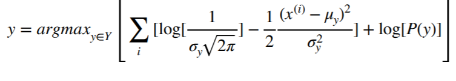

, where  
train_features: (N, 8)  
$\mu_y$: (8, 2)  
$\sigma_y$ (8, 2)

Part 1. $\log [P(y)]$ Shape: (2, 1)

Part 2. $\log(\frac{1}{\sigma_y\sqrt{2\pi}})$ : Compute using sigma_y. Straight forward. Shape: (8, 2)

Part 3. $-\frac{ (x^{(i)} - \mu_y)^2 }{2\sigma_y^2}$ Two (5, 8)s

The three variables that need to be used, train_features, mu_y, and sigma_y, have different shapes; (5, 8), (8, 2), and (8, 2), respectively. So you cannot just do train_features - mu_y. mu_y has both y == 0 and y == 1 component. The final answer also has both y == 0 component and y == 1 component. So, take y == 0 component from mu_y to do the math and do another with y == 1 component. The same logic applies to sigma_y during the computation. Shape of the result for one component: (5, 8), same as that of train_features. There are two of these.

Part 4. The final math is: for each component of y, $\sum_{}^{}(Part2 + Part3)+Part1$ . Reminder, both Part 1 and Part 2 have y == 0 and y == 1 component.

Part 5. Finally, I put together the final answer by arranging and transposing the two components. i.e. log_p_x_y = np.transpose(np.array([log_p_x_y_0, log_p_x_y_1])). Shape: (5, 2).

```python
some_feats = np.array([[  1. ,  85. ,  66. ,  29. ,   0. ,  26.6,   0.4,  31. ],
                       [  8. , 183. ,  64. ,   0. ,   0. ,  23.3,   0.7,  32. ],
                       [  1. ,  89. ,  66. ,  23. ,  94. ,  28.1,   0.2,  21. ],
                       [  0. , 137. ,  40. ,  35. , 168. ,  43.1,   2.3,  33. ],
                       [  5. , 116. ,  74. ,   0. ,   0. ,  25.6,   0.2,  30. ]])
some_labels = np.array([0, 1, 0, 1, 0])

some_mu_y = cc_mean_ignore_missing(some_feats, some_labels)
some_std_y = cc_std_ignore_missing(some_feats, some_labels)
some_log_py = log_prior(some_labels)
N, d = train_features.shape
#part 2
p2 = np.log((sigma_y * np.sqrt(2*np.pi))**-1) #(8,2)
p2_0 = p2[:,0]
p2_1 = p2[:,1]

#part 3
# -1 * (((8,5) - (8,1))/(8,1))
p3_0 = -1*((some_feats.T - mu_y[:, 0].reshape(d,1))**2  / (2 * some_std_y[:, 0].reshape(d,1)**2) ) #(N,8)
p3_1 = -1*((some_feats.T - mu_y[:, 1].reshape(d,1))**2  / (2 * some_std_y[:, 1].reshape(d,1)**2) ) #(N,8)

p1_0 = some_log_py[0,0] #scalar
p1_1 = some_log_py[1,0] #scalar

#result should be (N,2)
# part 2: (8,) (d,)
# part 3: (5,8) (N,d)
#                    d,N               d,1
log_p_x_y = np.array([np.sum(p3_0 + p2_0.reshape(8,1), axis = 0) + p1_0, np.sum(p3_1 + p2_1.reshape(8,1), axis = 0) + p1_1]).T #(5,2) = (N,2)
log_p_x_y.shape
```

```
(5, 2)
```

```python
def log_prob(train_features, mu_y, sigma_y, log_py):
    N, d = train_features.shape

    #part 2
    p2 = np.log((sigma_y * np.sqrt(2*np.pi))**-1) #(8,2)
    p2_0 = p2[:,0]
    p2_1 = p2[:,1]

    #part 3
    # -1 * (((8,5) - (8,1))/(8,1))
    p3_0 = -1*((some_feats.T - mu_y[:, 0].reshape(d,1))**2  / (2 * some_std_y[:, 0].reshape(d,1)**2) ) #(N,8)
    p3_1 = -1*((some_feats.T - mu_y[:, 1].reshape(d,1))**2  / (2 * some_std_y[:, 1].reshape(d,1)**2) ) #(N,8)

    p1_0 = some_log_py[0,0] #scalar
    p1_1 = some_log_py[1,0] #scalar

    #result should be (N,2)
    # part 2: (8,) (d,)
    # part 3: (5,8) (N,d)
    #                    d,N               d,1
    log_p_x_y = np.array([np.sum(p3_0 + p2_0.reshape(8,1), axis = 0) + p1_0, np.sum(p3_1 + p2_1.reshape(8,1), axis = 0) + p1_1]).T #(5,2) = (N,2)

    assert log_p_x_y.shape == (N,2)
    return log_p_x_y
```

```python
# Performing sanity checks on your implementation
some_feats = np.array([[  1. ,  85. ,  66. ,  29. ,   0. ,  26.6,   0.4,  31. ],
                       [  8. , 183. ,  64. ,   0. ,   0. ,  23.3,   0.7,  32. ],
                       [  1. ,  89. ,  66. ,  23. ,  94. ,  28.1,   0.2,  21. ],
                       [  0. , 137. ,  40. ,  35. , 168. ,  43.1,   2.3,  33. ],
                       [  5. , 116. ,  74. ,   0. ,   0. ,  25.6,   0.2,  30. ]])
some_labels = np.array([0, 1, 0, 1, 0])

some_mu_y = cc_mean_ignore_missing(some_feats, some_labels)
some_std_y = cc_std_ignore_missing(some_feats, some_labels)
some_log_py = log_prior(some_labels)

some_log_p_x_y = log_prob(some_feats, some_mu_y, some_std_y, some_log_py)

assert np.array_equal(some_log_p_x_y.round(3), np.array([[ -20.822,  -36.606],
                                                         [ -60.879,  -27.944],
                                                         [ -21.774, -295.68 ],
                                                         [-417.359,  -27.944],
                                                         [ -23.2  ,  -42.6  ]]))

# Checking against the pre-computed test database
test_results = test_case_checker(log_prob, task_id=4)
assert test_results['passed'], test_results['message']
```

[output not shown]

[output cut: 46 more lines]

[output not shown]

```python
# This cell is left empty as a seperator. You can leave this cell as it is, and you should not delete it.
```

```python
log_p_x_y = log_prob(train_features, mu_y, sigma_y, log_py)
log_p_x_y
```

[output not shown]